# Investigate a Dataset

### 项目要求

对[泰坦尼克号数据](https://github.com/ShiChJ/DAND-Basic-Materials/blob/master/P2/Project_Files/titanic-data.csv)进行数据分析，创建并分享数据分析文档。利用`Pandas`和`NumPy`操作数据，进行数据可视化分析，最终回答你感兴趣的问题

### 数据集加载及处理

```python
import numpy as np
import pandas as pd
from pandas import DataFrame
import matplotlib.pyplot as plt
import seaborn as sns

sns.set(style="whitegrid", color_codes=True)
data = pd.read_csv('titanic-data.csv')
```

```python
# 数据规模
data.shape
```

```
(891, 12)
```

该数据集含有12个参数和891条信息

```python
# 查看数据集前五行的具体信息
data.head()
```

|  | PassengerId | Survived | Pclass | Name | Sex | Age | SibSp | Parch | Ticket | Fare | Cabin | Embarked |
| --- | --- | --- | --- | --- | --- | --- | --- | --- | --- | --- | --- | --- |
| 0 | 1 | 0 | 3 | Braund, Mr. Owen Harris | male | 22.0 | 1 | 0 | A/5 21171 | 7.2500 | NaN | S |
| 1 | 2 | 1 | 1 | Cumings, Mrs. John Bradley (Florence Briggs Th... | female | 38.0 | 1 | 0 | PC 17599 | 71.2833 | C85 | C |
| 2 | 3 | 1 | 3 | Heikkinen, Miss. Laina | female | 26.0 | 0 | 0 | STON/O2. 3101282 | 7.9250 | NaN | S |
| 3 | 4 | 1 | 1 | Futrelle, Mrs. Jacques Heath (Lily May Peel) | female | 35.0 | 1 | 0 | 113803 | 53.1000 | C123 | S |
| 4 | 5 | 0 | 3 | Allen, Mr. William Henry | male | 35.0 | 0 | 0 | 373450 | 8.0500 | NaN | S |

在`Cabin`这一列出现了`NaN`，需要进行缺省值处理，同时我们可以忽略一些信息：`Name`,`Ticket`,`Embarked`

```python
# 保留数据分析时需要的信息
chosen_data = data.loc[:,['PassengerId','Survived', 'Pclass', 'Sex', 'Age','SibSp','Parch','Fare', ]]

# 缺省值处理
clean_data = chosen_data.dropna()

# 数据集信息
clean_data.describe()
```

|  | PassengerId | Survived | Pclass | Age | SibSp | Parch | Fare |
| --- | --- | --- | --- | --- | --- | --- | --- |
| count | 714.000000 | 714.000000 | 714.000000 | 714.000000 | 714.000000 | 714.000000 | 714.000000 |
| mean | 448.582633 | 0.406162 | 2.236695 | 29.699118 | 0.512605 | 0.431373 | 34.694514 |
| std | 259.119524 | 0.491460 | 0.838250 | 14.526497 | 0.929783 | 0.853289 | 52.918930 |
| min | 1.000000 | 0.000000 | 1.000000 | 0.420000 | 0.000000 | 0.000000 | 0.000000 |
| 25% | 222.250000 | 0.000000 | 1.000000 | 20.125000 | 0.000000 | 0.000000 | 8.050000 |
| 50% | 445.000000 | 0.000000 | 2.000000 | 28.000000 | 0.000000 | 0.000000 | 15.741700 |
| 75% | 677.750000 | 1.000000 | 3.000000 | 38.000000 | 1.000000 | 1.000000 | 33.375000 |
| max | 891.000000 | 1.000000 | 3.000000 | 80.000000 | 5.000000 | 6.000000 | 512.329200 |

通过数据清洗后，我们可以得到一些浅显的信息：1. 可以使用的信息有714条；2. 乘客的平均年龄为29.7岁。接下来我们就可以利用处理好的数据集来解答我们的一些问题。

### 数据分析问题

利用seaborn和matplotlib.pyplot进行数据可视化，提高我们的分析效率

#### 不同的因素与生还率的相关性

```python
# 不同列数据间的相关性
clean_data.corr()
```

|  | PassengerId | Survived | Pclass | Age | SibSp | Parch | Fare |
| --- | --- | --- | --- | --- | --- | --- | --- |
| PassengerId | 1.000000 | 0.029340 | -0.035349 | 0.036847 | -0.082398 | -0.011617 | 0.009592 |
| Survived | 0.029340 | 1.000000 | -0.359653 | -0.077221 | -0.017358 | 0.093317 | 0.268189 |
| Pclass | -0.035349 | -0.359653 | 1.000000 | -0.369226 | 0.067247 | 0.025683 | -0.554182 |
| Age | 0.036847 | -0.077221 | -0.369226 | 1.000000 | -0.308247 | -0.189119 | 0.096067 |
| SibSp | -0.082398 | -0.017358 | 0.067247 | -0.308247 | 1.000000 | 0.383820 | 0.138329 |
| Parch | -0.011617 | 0.093317 | 0.025683 | -0.189119 | 0.383820 | 1.000000 | 0.205119 |
| Fare | 0.009592 | 0.268189 | -0.554182 | 0.096067 | 0.138329 | 0.205119 | 1.000000 |

通过`Pandas`的`corr()`函数我们可以便捷的得到各因素之间的相关性，但是因为`Sex`数据的格式为字符串，所以未显示在表格中，让我们来单独分析**性别对生还率的影响**

#### 性别对生还率的影响

首先，我们来看看男女各自的人数

```python
# 男女人数
clean_data.groupby('Sex')['PassengerId'].count()
```

```
Sex
female    261
male      453
Name: PassengerId, dtype: int64
```

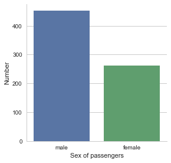

```python
# 男女人数直方图
Number_Of_Sex = sns.factorplot("Sex",data=clean_data ,kind='count')
Number_Of_Sex.set_ylabels("Number")
Number_Of_Sex.set_xlabels("Sex of passengers")
```

根据以上的分析，我们发现乘客中的男性的人数为453人，女性人数为261人。然后，分析男性和女性生还人数在总人数中所占的比例

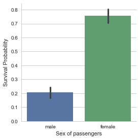

```python
# 男女各自生还人数比例图
Survived_Of_Sex = sns.factorplot("Sex","Survived",data=clean_data ,kind='bar')
Survived_Of_Sex.set_ylabels("Survival Probability")
Survived_Of_Sex.set_xlabels("Sex of passengers")
```

**结论**：由以上的两幅图标我们可以看出，虽然乘客中男性所占的比例很高，但是女性生还的可能性更大。但是我们不应该认为性别是影响生还率的唯一因素。

#### 阶层和年龄对生还率的影响

接下来分析`Pclass`和`Age`对`Survived`的影响。 首先让我们来看看各阶层的生还率是多少。

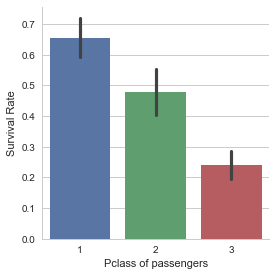

```python
# 各阶层的生还率
Survived_Of_Pclass = sns.factorplot("Pclass","Survived",data=clean_data ,kind='bar')
Survived_Of_Pclass.set_ylabels("Survival Rate")
Survived_Of_Pclass.set_xlabels("Pclass of passengers")
```

根据上图，我们不难发现阶层越高，越容易生还。但是会不会因为**乘客中第一阶层的人数较多**，从而影响了生还率呢？让我们接着分析各阶层的人数比例，看看我们的猜想是否正确。

```python
# 各阶层的人数
clean_data.groupby('Pclass')['PassengerId'].count()
```

```
Pclass
1    186
2    173
3    355
Name: PassengerId, dtype: int64
```

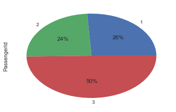

```python
clean_data.groupby('Pclass')['PassengerId'].count().plot(kind = 'pie', autopct = '%.0f%%')
```

根据饼状图我们可以清晰的看出，第一阶层所占的比例仅为26%，但是它的生还率却是最高的！ 考虑到我们的第一个问题的结论：女性的生还率更高。猜想：**女性在各阶层的比例**会干扰阶层对生还率的影响

```python
# 提取出只包含第一阶层相关数据的数据集
group1 = clean_data[clean_data['Pclass']==1]
group2 = clean_data[clean_data['Pclass']==2]
group3 = clean_data[clean_data['Pclass']==3]
```

```python
# 第一阶层的男女比例
group1.groupby('Sex').size() * 100 / group1.shape[0]
```

```
Sex
female    45.698925
male      54.301075
dtype: float64
```

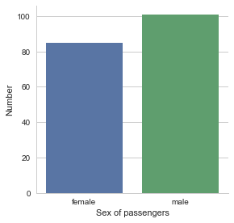

```python
#第一阶层男女乘客的人数
Number_Of_Sex_in_Pclass1 = sns.factorplot("Sex",data=group1 ,kind='count')
Number_Of_Sex_in_Pclass1.set_ylabels("Number")
Number_Of_Sex_in_Pclass1.set_xlabels("Sex of passengers")
```

```python
group2.groupby('Sex').size() * 100 / group2.shape[0]
```

```
Sex
female    42.774566
male      57.225434
dtype: float64
```

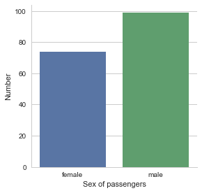

```python
#第二阶层男女乘客的人数
Number_Of_Sex_in_Pclass2 = sns.factorplot("Sex",data=group2 ,kind='count')
Number_Of_Sex_in_Pclass2.set_ylabels("Number")
Number_Of_Sex_in_Pclass2.set_xlabels("Sex of passengers")
```

```python
group3.groupby('Sex').size() * 100 / group3.shape[0]
```

```
Sex
female    28.732394
male      71.267606
dtype: float64
```

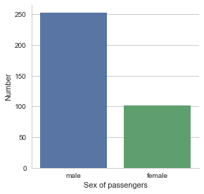

```python
#第三阶层男女乘客的人数
Number_Of_Sex_in_Pclass3 = sns.factorplot("Sex",data=group3 ,kind='count')
Number_Of_Sex_in_Pclass3.set_ylabels("Number")
Number_Of_Sex_in_Pclass3.set_xlabels("Sex of passengers")
```

由以上三幅图表可以看出：女性在各个阶层中所占的比例都小于男性。

接下来，通过可视化生还组和死亡组的年龄分布分析年龄对生还率有何影响。

```python
# 提取生还组和死亡组的数据集
survived=clean_data[clean_data['Survived']==1]
dead=clean_data[clean_data['Survived']==0]
```

```
Text(0,0.5,'Frequency')
```

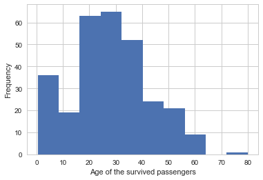

```python
plt.hist(survived['Age'])
plt.xlabel('Age of the survived passengers')
plt.ylabel('Frequency')
```

```
Text(0,0.5,'Frequency')
```

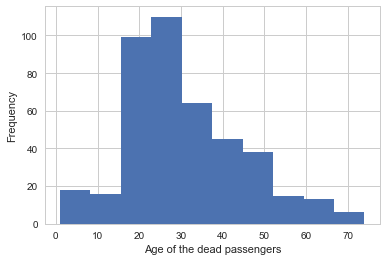

```python
plt.hist(dead['Age'])
plt.xlabel('Age of the dead passengers')
plt.ylabel('Frequency')
```

**结论2**：我们看到年龄小于15岁的孩子更有可能得救。我们可以通过计算Age和Survived的相关系数来验证我们的结论

```python
age_sur = clean_data.loc[:,['Survived', 'Age']]
age_sur.corr()
```

|  | Survived | Age |
| --- | --- | --- |
| Survived | 1.000000 | -0.077221 |
| Age | -0.077221 | 1.000000 |

### 总结

其实我们还可以提出更多的猜想，比如：水手的生还率是否更高呢？但是发现数据集中并没有相关的数据。其次，根据维基百科，大约有1317名乘客，但数据集只有891名乘客，这严重限制了我们得出明确结论的能力。这就体现了数据局限性对数据分析准确率的重大影响。

### 参考

https://discussions.udacity.com

https://stackoverflow.com

https://matplotlib.org

https://seaborn.pydata.org/index.html

https://github.com